# Análisis Factorial Confirmatorio

Anais Herrera-Leighton

```r
pacman::p_load(lavaan, sjPlot, haven, dplyr)
```

# Cargar bbdd

```r
ola1<-read_dta("../input/data/proc/data_01.dta")
ola2<-read_dta("../input/data/proc/data_02.dta")
ola3<-read_dta("../input/data/proc/data_03.dta")
```

# Juntar bbdd

```r
data_wide <- full_join(x = ola1, #datos ola 1
y = ola2, #datos ola 2
by = "folio_encuestado", #identificador
#aplica sufijo a variables que se repiten entre olas
suffix = c("_w01",
"_w02")) %>%
left_join(ola3,
by = "folio_encuestado")
```

# Tipos de participación y frases a utilizar

**Activismo no disruptivo**

- Firmar una petición, presencialmente o por internet
- Participar en una marcha o manifestación pacífica

**Activismo disruptivo**

- Participar en una marcha o manifestación con disturbios
- Participar en bloqueo de calles o carreteras
- Pintar o rayar paredes con demandas o consignas
- Participar en la toma de un edificio o institución

**Activismo online**

- Usar internet para buscar información sobre temas sociales y/o políticos
- Postear imágenes o mensajes acerca de temas sociales y/o políticos en internet
- Compartir o comentar en el posteo de otra persona acerca de temas sociales y políticos
- Seguir a personas en redes sociales por su contenido sobre temas sociales y políticos

**Activismo social o comunitario**

- Trabajar como voluntario en servicios a la comunidad (debido a que es sólo un indicador, *no* se incorporará en el AFC)

# Introducción al Análisis Factorial Confirmatorio (AFC)

## Variable ejemplo: Participación política durante 3ro y 4to medio

### Descriptivos

```r
part_pol_3y4= data_wide %>% dplyr::select(part_pol_firma_w01, part_pol_marcha_pas, part_pol_marcha_dis, part_pol_bloqueo, part_pol_rayar_w01, part_pol_toma_w01, part_pol_online, part_online_post, part_online_com, part_online_seg)
summary(part_pol_3y4)
```

```
##  part_pol_firma_w01 part_pol_marcha_pas part_pol_marcha_dis part_pol_bloqueo
##  Min.   :1.000      Min.   :1.000       Min.   :1.000       Min.   :1.000
##  1st Qu.:1.000      1st Qu.:1.000       1st Qu.:1.000       1st Qu.:1.000
##  Median :2.000      Median :2.000       Median :1.000       Median :1.000
##  Mean   :1.918      Mean   :2.207       Mean   :1.703       Mean   :1.437
##  3rd Qu.:3.000      3rd Qu.:3.000       3rd Qu.:2.000       3rd Qu.:1.000
##  Max.   :4.000      Max.   :4.000       Max.   :4.000       Max.   :4.000
##  NA's   :577        NA's   :577         NA's   :577         NA's   :577
##  part_pol_rayar_w01 part_pol_toma_w01 part_pol_online part_online_post
##  Min.   :1.000      Min.   :1.000     Min.   :1.000   Min.   :1.000
##  1st Qu.:1.000      1st Qu.:1.000     1st Qu.:2.000   1st Qu.:1.000
##  Median :1.000      Median :1.000     Median :3.000   Median :2.000
##  Mean   :1.277      Mean   :1.532     Mean   :2.823   Mean   :2.199
##  3rd Qu.:1.000      3rd Qu.:2.000     3rd Qu.:4.000   3rd Qu.:3.000
##  Max.   :4.000      Max.   :4.000     Max.   :4.000   Max.   :4.000
##  NA's   :577        NA's   :577       NA's   :603     NA's   :603
##  part_online_com part_online_seg
##  Min.   :1.000   Min.   :1.000
##  1st Qu.:1.000   1st Qu.:1.000
##  Median :2.000   Median :2.000
##  Mean   :2.112   Mean   :2.222
##  3rd Qu.:3.000   3rd Qu.:3.000
##  Max.   :4.000   Max.   :4.000
##  NA's   :603     NA's   :603
```

### Análisis correlacional

```r
corMat  <- cor(part_pol_3y4, use="na.or.complete", method = "kendall")  # estimar matriz pearson
options(digits=3) # decimales
#print(corMat)

#stargazer::stargazer(corMat, title="correlaciones", type = "text") #Latex table
```

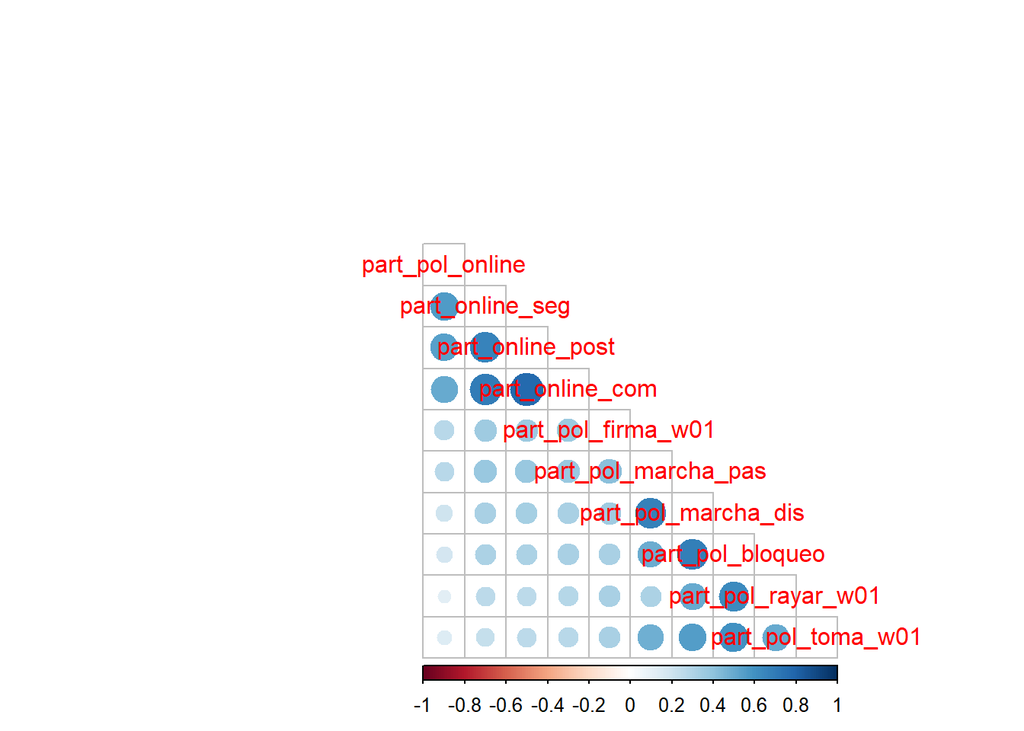

```r
M=cor(part_pol_3y4, use="na.or.complete")
corrplot::corrplot(M, type="lower",
      order="AOE", cl.pos="b", tl.pos="d") #agrega nombres en diag.
```

[figure not shown]

```r
sjPlot::sjp.corr(part_pol_3y4, na.deletion = c("listwise"))
```

### **AFC**

La mayor parte de las mediciones en ciencias sociales son atributos latentes. Lo que se hace típicamente es construir instrumentos que capturaran los conceptos a partir de más de un indicador. En este sentido, lo que se hace es intentar capturar una dimensión latente a partir de atributos (o indicadores) observados.

El Análisis Factorial Confirmatorio es una técnica orientada a evaluar la validez de la medición de estos constructos latentes (es decir, evaluar si se está midiendo lo que se quiere medir). Dado que los constructos latentes se miden a partir de indicadores observables (o ítems), lo que se hace es evaluar el grado en que los múltiples indicadores covarían entre ellos.

Esto se relaciona con la teoría clásica del test. Como un test puede ser medido a partir de un constructo latente. La teoría dice que el puntaje de un factor latente tiene dos componentes: puntaje verdadero (aquello que realmente es el atributo que estamos capturando) y puntaje error. Al utilizar un sólo indicador se está asumiendo que todo es puntaje verdadero, se asume que ese proxy es suficiente para dar cuenta del constructo, lo cual es un supuesto demasiado grande. Por ende, se busca capturar los constructos latentes a partir de múltiples indicadores, lo que nos permite separar la varianza común (que comparten entre si) de la varianza única (aquella parte del indicador que no es común con el resto). Y, dado que el grupo de indicadores comparte varianza entre sí, se puede asumir que está siendo explicada por un factor latente.

#### **Análisis de supuestos**

Es relevante preguntarse si ¿hay suficientes correlaciones para pensar que habrá un factor que subyace o explica las correlaciones? antes de pensar en hacer el análisis. Por este motivo es que hacemos la matriz de correlacciones. Hay que fijarse en la dirección, magnitud y significancia.

En relación a las magnitudes es relevante revisar si hay indicadores que tienen correlaciones más altas entre sí que con otros indicadores, ya que esto de algún modo podría indicar que esos elementos tienen mas varianza común que con los otros (y, por ende, puede que correspondan a una misma subdimensión).

##### **KMO: factorizabilidad**

```r
psych::KMO(corMat)
```

```
## Kaiser-Meyer-Olkin factor adequacy
## Call: psych::KMO(r = corMat)
## Overall MSA =  0.85
## MSA for each item =
##  part_pol_firma_w01 part_pol_marcha_pas part_pol_marcha_dis    part_pol_bloqueo
##                0.93                0.84                0.83                0.84
##  part_pol_rayar_w01   part_pol_toma_w01     part_pol_online    part_online_post
##                0.85                0.90                0.89                0.83
##     part_online_com     part_online_seg
##                0.82                0.88
```

Los criterios para analizar el valor del estadístico KMO son:

- 0.00 to 0.49 inaceptable.
- 0.50 to 0.59 miserable.
- 0.60 to 0.69 mediocre.
- 0.70 to 0.79 medio.
- 0.80 to 0.89 meritorio.
- 0.90 to 1.00 maravilloso.

##### **Esfericidad**

```r
psych::cortest.bartlett(corMat, n = 3432) #el n que se debe indicar es el número de casos de la base de datos que estamos utilizando para el análisis
```

```
## $chisq
## [1] 13738
##
## $p.value
## [1] 0
##
## $df
## [1] 45
```

Este criterio alude a en qué medida la varianza de la matriz es suficiente. Si rechazamos la hipótesis nula (p=<0.05) de que la varianza es 0, significa que hay suficientes elementos comunes. En este sentido, como la hipótesis nula es que no hay relaciones, esperamos rechazarla.

##### **Normalidad (univariada)**

```r
shapiro.test(part_pol_3y4$part_pol_firma_w01)
```

```
##
##  Shapiro-Wilk normality test
##
## data:  part_pol_3y4$part_pol_firma_w01
## W = 0.8, p-value <2e-16
```

Este test se debe aplicar a cada una de las variables.

Recordatorio: la hipótesis nula de este test es que la variable se distribuye normalmente. Por lo que si el valor de p es menor o igual a 0.05, se rechaza la hipótesis nula y hay evidencia de que la variable no se distribuye normalmente.

La normalidad de los indicadores no es tan relevante porque hay métodos robustos a la no normalidad, pero por esto mismo es necesario hacer el análisis para elegir el método más adecuado. Por ejemplo, el método de máxima verosimilitud (ml) solo se debe usar cuando las variables si tienen una distribución normal.

#### **Especificación y estimación del modelo**

```r
# Especificación del modelo
afc1 <- '
act_no_disrup =~ part_pol_firma_w01 + part_pol_marcha_pas
act_disrup =~ part_pol_marcha_dis + part_pol_bloqueo + part_pol_rayar_w01 + part_pol_toma_w01
act_online =~ part_pol_online + part_online_post + part_online_com + part_online_seg
'
```

```r
# Estimación del modelo
fit_1 <- lavaan::cfa(afc1, data=part_pol_3y4, ordered=T)
```

#### **Interpretación de resultados**

La estimación arroja una serie de informaciones, tales como ajuste, parámetros estimados, medidas estandarizadas, posibles modificaciones, entre otros (todos los resultados se muestran bajo el código summary). Sin embargo, en esta práctica nos centraremos solo en el ajuste general y solución estandarizada.

```r
lavaan::summary(fit_1, fit.measures=T, standardized=T)
```

```
## lavaan 0.6-11 ended normally after 30 iterations
##
##   Estimator                                       DWLS
##   Optimization method                           NLMINB
##   Number of model parameters                        43
##
##                                                   Used       Total
##   Number of observations                          2829        3432
##
## Model Test User Model:
##                                               Standard      Robust
##   Test Statistic                               372.145     576.801
##   Degrees of freedom                                32          32
##   P-value (Chi-square)                           0.000       0.000
##   Scaling correction factor                                  0.654
##   Shift parameter                                            7.941
##        simple second-order correction
##
## Model Test Baseline Model:
##
##   Test statistic                             81837.774   41208.784
##   Degrees of freedom                                45          45
##   P-value                                        0.000       0.000
##   Scaling correction factor                                  1.987
##
## User Model versus Baseline Model:
##
##   Comparative Fit Index (CFI)                    0.996       0.987
##   Tucker-Lewis Index (TLI)                       0.994       0.981
##
##   Robust Comparative Fit Index (CFI)                            NA
##   Robust Tucker-Lewis Index (TLI)                               NA
##
## Root Mean Square Error of Approximation:
##
##   RMSEA                                          0.061       0.078
##   90 Percent confidence interval - lower         0.056       0.072
##   90 Percent confidence interval - upper         0.067       0.083
##   P-value RMSEA <= 0.05                          0.000       0.000
##
```

[output cut: 100 more lines]

```
##     act_disrup        0.852    0.013   63.887    0.000    1.000    1.000
##     act_online        0.486    0.018   27.413    0.000    1.000    1.000
##
## Scales y*:
##                    Estimate  Std.Err  z-value  P(>|z|)   Std.lv  Std.all
##     prt_pl_frm_w01    1.000                               1.000    1.000
##     prt_pl_mrch_ps    1.000                               1.000    1.000
##     prt_pl_mrch_ds    1.000                               1.000    1.000
##     part_pol_bloqu    1.000                               1.000    1.000
##     prt_pl_ryr_w01    1.000                               1.000    1.000
##     part_pl_tm_w01    1.000                               1.000    1.000
##     part_pol_onlin    1.000                               1.000    1.000
##     part_onlin_pst    1.000                               1.000    1.000
##     part_online_cm    1.000                               1.000    1.000
##     part_online_sg    1.000                               1.000    1.000
```

La función *show* nos muestra el principio de la tabla anterior, donde se presenta el tipo de estimador usado, la medida de ajuste de $\chi^2$ del modelo y los grados de libertad

```r
show(fit_1) # Resumen ajuste general
```

```
## lavaan 0.6-11 ended normally after 30 iterations
##
##   Estimator                                       DWLS
##   Optimization method                           NLMINB
##   Number of model parameters                        43
##
##                                                   Used       Total
##   Number of observations                          2829        3432
##
## Model Test User Model:
##                                               Standard      Robust
##   Test Statistic                               372.145     576.801
##   Degrees of freedom                                32          32
##   P-value (Chi-square)                           0.000       0.000
##   Scaling correction factor                                  0.654
##   Shift parameter                                            7.941
##        simple second-order correction
```

El estimador DWLS es uno de los estimadores que se recomiendan para los casos en que no se cumple con el supuesto de normalidad de las variables.

**En relación al $\chi^2$, cabe destacar que se espera no rechazar la hipótesis nula**, es decir, que el test no sea estadísticamente significativo, ya que implicaría que la matriz de varianzas-covarianzas observadas y la matriz implicada en el modelo no difieren significativamente. Además, se debe evaluar **el valor de $\chi^2$/Df y se espera que el valor sea igual o menor a 4.**

Es usual que no los resultados de este indicador muestren que el ajuste no es adecuado cuando el número de casos es alto, por lo que es importante evaluar también la evidencia que brinda los otros indicadores.

```r
lavaan::fitMeasures(fit_1, c("chisq", "df", "pvalue", "cfi", "tli", "rmsea", "srmr"))
```

```
##   chisq      df  pvalue     cfi     tli   rmsea    srmr
## 372.145  32.000   0.000   0.996   0.994   0.061   0.049
```

**Rangos recomendados:**

- CFI: Cercano a 0.95 o más
- TLI: Cercano a 0.95 o más
- RMSEA: Cercano a 0.06 o menos
- SRMR: Cercano a 0.08 o menos